# Spotify Songs Analysis

## Visualizations of Song Analysis

### Does Danceability Affect Track Popularity?

This scatterplot aims to answer whether danceability affect track popularity. We used a scatterplot because we wanted to see whether there was a correlation between danceability and popularity. Track popularity ranges from 0 - 100 with 100 being the most popular. The scatterplot shows a weak correlation between danceability and popularity. Popularity is mostly random with respect to danceability although we can see *roughly* that most of the popular songs have a high danceability of above a 0.65.

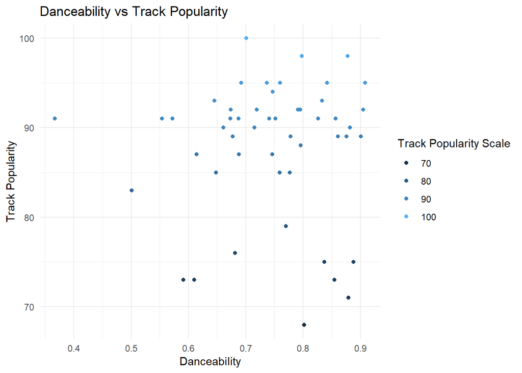

### Comparing Valence With One Another

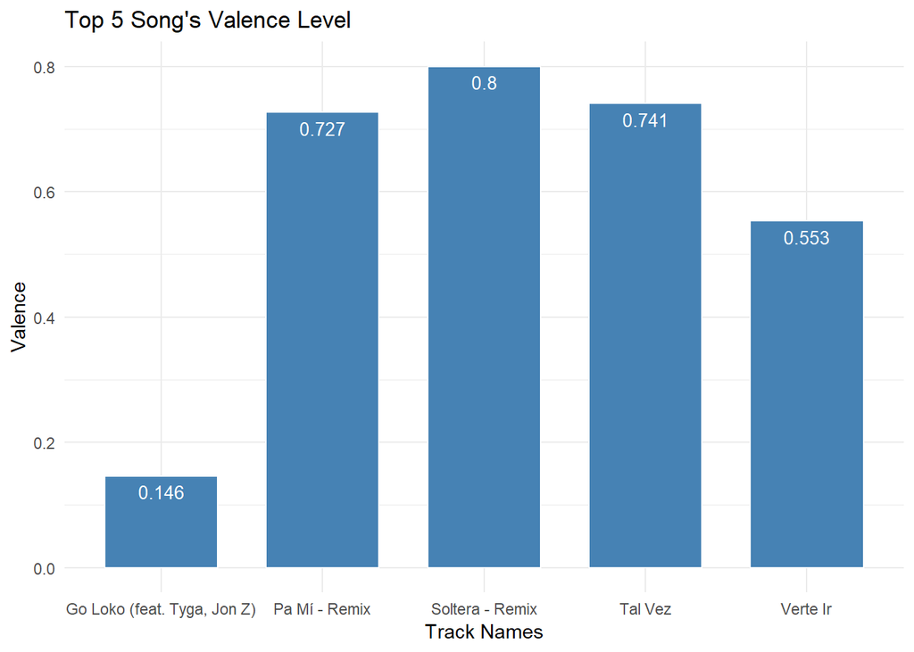

### Count of Songs That Are Explicit and In a Certain Key

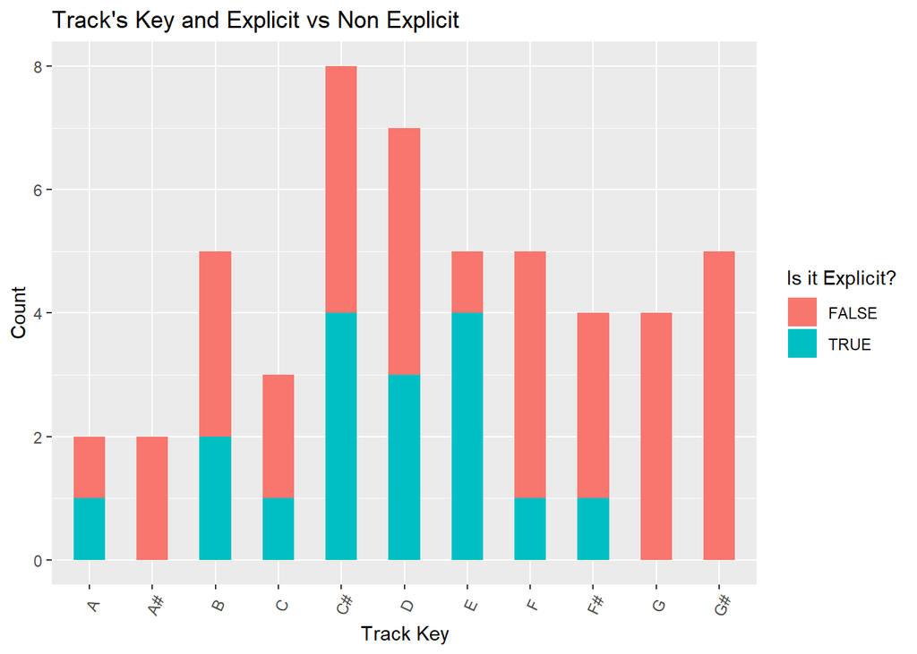